# Lab 4: Tidy Data Case Study

FIRSTNAME LASTNAME

九月 11, 2020

# Introduction

To finish off Chapter 9, let’s pull together everything you’ve learned to tackle a realistic data tidying problem. The `tidyr::who` dataset contains tuberculosis (TB) cases broken down by year, country, age, gender, and diagnosis method. The data comes from the 2014 World Health Organization Global Tuberculosis Report, available at http://www.who.int/tb/country/data/download/en/.

There’s a wealth of epidemiological information in this dataset (7240 rows, 60 columns), but it’s challenging to work with the data in the form that it’s provided:

```r
head(who,10)
```

```
## # A tibble: 10 x 60
##    country iso2  iso3   year new_sp_m014 new_sp_m1524 new_sp_m2534 new_sp_m3544
##    <chr>   <chr> <chr> <int>       <int>        <int>        <int>        <int>
##  1 Afghan~ AF    AFG    1980          NA           NA           NA           NA
##  2 Afghan~ AF    AFG    1981          NA           NA           NA           NA
##  3 Afghan~ AF    AFG    1982          NA           NA           NA           NA
##  4 Afghan~ AF    AFG    1983          NA           NA           NA           NA
##  5 Afghan~ AF    AFG    1984          NA           NA           NA           NA
##  6 Afghan~ AF    AFG    1985          NA           NA           NA           NA
##  7 Afghan~ AF    AFG    1986          NA           NA           NA           NA
##  8 Afghan~ AF    AFG    1987          NA           NA           NA           NA
##  9 Afghan~ AF    AFG    1988          NA           NA           NA           NA
## 10 Afghan~ AF    AFG    1989          NA           NA           NA           NA
## # ... with 52 more variables: new_sp_m4554 <int>, new_sp_m5564 <int>,
## #   new_sp_m65 <int>, new_sp_f014 <int>, new_sp_f1524 <int>,
## #   new_sp_f2534 <int>, new_sp_f3544 <int>, new_sp_f4554 <int>,
## #   new_sp_f5564 <int>, new_sp_f65 <int>, new_sn_m014 <int>,
## #   new_sn_m1524 <int>, new_sn_m2534 <int>, new_sn_m3544 <int>,
## #   new_sn_m4554 <int>, new_sn_m5564 <int>, new_sn_m65 <int>,
## #   new_sn_f014 <int>, new_sn_f1524 <int>, new_sn_f2534 <int>,
## #   new_sn_f3544 <int>, new_sn_f4554 <int>, new_sn_f5564 <int>,
## #   new_sn_f65 <int>, new_ep_m014 <int>, new_ep_m1524 <int>,
## #   new_ep_m2534 <int>, new_ep_m3544 <int>, new_ep_m4554 <int>,
## #   new_ep_m5564 <int>, new_ep_m65 <int>, new_ep_f014 <int>,
## #   new_ep_f1524 <int>, new_ep_f2534 <int>, new_ep_f3544 <int>,
## #   new_ep_f4554 <int>, new_ep_f5564 <int>, new_ep_f65 <int>,
## #   newrel_m014 <int>, newrel_m1524 <int>, newrel_m2534 <int>,
## #   newrel_m3544 <int>, newrel_m4554 <int>, newrel_m5564 <int>,
## #   newrel_m65 <int>, newrel_f014 <int>, newrel_f1524 <int>,
## #   newrel_f2534 <int>, newrel_f3544 <int>, newrel_f4554 <int>,
## #   newrel_f5564 <int>, newrel_f65 <int>
```

This is a very typical real-life example dataset. It contains redundant columns, odd variable codes, and many missing values. In short, `who` is messy, and we’ll need multiple steps to tidy it. Like dplyr, tidyr is designed so that each function does one thing well. That means in real-life situations you’ll usually need to string together multiple verbs into a pipeline.

When you get the desired result for each step, change `Eval=F` to `Eval=T` and knit the document to HTML to make sure it works. After you complete the lab, you should submit your HTML file of what you have completed on Sakai before the deadline.

# Part 1: Gather Variables Together

Some observations on the data:

- It looks like `country`, `iso2`, and `iso3` are three variables that redundantly specify the country.
- `year` is clearly also a varialbe.
- We don’t know what all the other columns are yet, but given the structure in the variable names (e.g. `new_sp_m014`, `new_ep_m014`, `new_ep_f014`) these are likely to be values, not variables.

## Q1: Gather together all the columns from new_sp_m014 to newrel_f65.

We don’t know what those values represent yet, so we’ll give them the generic name “key”. We know the cells represent the count of cases, so we’ll use the variable `cases`. There are a lot of missing values in the current representation, so for now we’ll use `values_drop_na` just so we can focus on the values that are present.

```r
who1 <- who %>%
  pivot_longer(
    cols = "new_sp_m014":"newrel_f65",
    names_to = "key",
    values_to = "cases",
    values_drop_na = TRUE
  )
head(who1,10)
```

```
## # A tibble: 10 x 6
##    country     iso2  iso3   year key          cases
##    <chr>       <chr> <chr> <int> <chr>        <int>
##  1 Afghanistan AF    AFG    1997 new_sp_m014      0
##  2 Afghanistan AF    AFG    1997 new_sp_m1524    10
##  3 Afghanistan AF    AFG    1997 new_sp_m2534     6
##  4 Afghanistan AF    AFG    1997 new_sp_m3544     3
##  5 Afghanistan AF    AFG    1997 new_sp_m4554     5
##  6 Afghanistan AF    AFG    1997 new_sp_m5564     2
##  7 Afghanistan AF    AFG    1997 new_sp_m65       0
##  8 Afghanistan AF    AFG    1997 new_sp_f014      5
##  9 Afghanistan AF    AFG    1997 new_sp_f1524    38
## 10 Afghanistan AF    AFG    1997 new_sp_f2534    36
```

## Q2: Separate key column

For the `key` column, the data dictionary tells us:

- The first three letters of each column denote whether the column contains new or old cases of TB. In this dataset, each column contains new cases.
- The next two letters describe the type of TB:
  - `rel` stands for cases of relapse
  - `ep` stands for cases of extrapulmonary TB
  - `sn` stands for cases of pulmonary TB that could not be diagnosed by a pulmonary smear (smear negative)
  - `sp` stands for cases of pulmonary TB that could be diagnosed be a pulmonary smear (smear positive)
- The sixth letter gives the sex of TB patients. The dataset groups cases by males (`m`) and females (`f`).
- The remaining numbers gives the age group. The dataset groups cases into seven age groups:
  - `014` = 0 – 14 years old
  - `1524` = 15 – 24 years old
  - `2534` = 25 – 34 years old
  - `3544` = 35 – 44 years old
  - `4554` = 45 – 54 years old
  - `5564` = 55 – 64 years old
  - `65` = 65 or older
- The names are slightly inconsistent for `key` because instead of `new_rel` we have `newrel`. Run the following code to make it consistent:

```r
who2 <- who1 %>%
  mutate(key = stringr::str_replace(key, "newrel", "new_rel"))
who2
```

```
## # A tibble: 76,046 x 6
##    country     iso2  iso3   year key          cases
##    <chr>       <chr> <chr> <int> <chr>        <int>
##  1 Afghanistan AF    AFG    1997 new_sp_m014      0
##  2 Afghanistan AF    AFG    1997 new_sp_m1524    10
##  3 Afghanistan AF    AFG    1997 new_sp_m2534     6
##  4 Afghanistan AF    AFG    1997 new_sp_m3544     3
##  5 Afghanistan AF    AFG    1997 new_sp_m4554     5
##  6 Afghanistan AF    AFG    1997 new_sp_m5564     2
##  7 Afghanistan AF    AFG    1997 new_sp_m65       0
##  8 Afghanistan AF    AFG    1997 new_sp_f014      5
##  9 Afghanistan AF    AFG    1997 new_sp_f1524    38
## 10 Afghanistan AF    AFG    1997 new_sp_f2534    36
## # ... with 76,036 more rows
```

## Q2: Separate the `key` column into columns `new`, `type` and `sexage`. Then drop the `new` column because it’s constant in this dataset. Please also drop `iso2`, `iso3` as they are also redundant.

```r
who3 <- who2 %>%
  separate("key", c("New","Type","Sexage"), sep = "_")%>% select(-c("New","iso2","iso3"))
```

## Q3: Separate the `sexage` column into columns `sex` and `age`. (Hint: if sep=Number, interpreted as positions to split at)

```r
who4 <- who3 %>%
  separate("Sexage", c("sex", "age"), sep=1)
```

## Q4: Put all steps in one code chunk with pipe operator

```r
who1 <- who %>%
  pivot_longer(
    cols = "new_sp_m014":"newrel_f65",
    names_to = "key",
    values_to = "cases",
    values_drop_na = TRUE
  )%>%  mutate(key = stringr::str_replace(key, "newrel", "new_rel"))%>%
  separate("key", c("New","Type","Sexage"), sep = "_") %>% select(-c("New","iso2","iso3")) %>%
  separate("Sexage", c("sex", "age"), sep = 1)
who1
```

```
## # A tibble: 76,046 x 6
##    country      year Type  sex   age   cases
##    <chr>       <int> <chr> <chr> <chr> <int>
##  1 Afghanistan  1997 sp    m     014       0
##  2 Afghanistan  1997 sp    m     1524     10
##  3 Afghanistan  1997 sp    m     2534      6
##  4 Afghanistan  1997 sp    m     3544      3
##  5 Afghanistan  1997 sp    m     4554      5
##  6 Afghanistan  1997 sp    m     5564      2
##  7 Afghanistan  1997 sp    m     65        0
##  8 Afghanistan  1997 sp    f     014       5
##  9 Afghanistan  1997 sp    f     1524     38
## 10 Afghanistan  1997 sp    f     2534     36
## # ... with 76,036 more rows
```

# More Exercises

First, let’s import a Comma Separated Values `.csv` file that exists on the internet. The `.csv` file `dem_score.csv` contains ratings of the level of democracy in different countries spanning 1952 to 1992 and is accessible at https://moderndive.com/data/dem_score.csv. Let’s use the `read_csv()` function from the `readr` package to read it off the web, import it into R, and save it in a data frame called `dem_score`. In the following part, we’re going to focuse on only data corresponding to Guatemala.

```r
dem_score <- read_csv("https://moderndive.com/data/dem_score.csv")
```

## Q5: In the following part, we’re going to focuse on only data corresponding to Guatemala.

```r
guat_dem <- dem_score %>%
  filter(country=="Guatemala")
guat_dem
```

```
## # A tibble: 1 x 10
##   country   `1952` `1957` `1962` `1967` `1972` `1977` `1982` `1987` `1992`
##   <chr>      <dbl>  <dbl>  <dbl>  <dbl>  <dbl>  <dbl>  <dbl>  <dbl>  <dbl>
## 1 Guatemala      2     -6     -5      3      1     -3     -7      3      3
```

## Q6: Gather the columns and put column names to a new variable `year` and put values to a new variable `democracy_score`. Make sure the `year` column is of integer type.

```r
guat_dem_tidy <- guat_dem %>%
  pivot_longer(cols = "1952":"1992",
               names_to ="Year",
               values_to = "Democracy_score") %>%
  mutate(Year=as.integer(Year))
guat_dem_tidy
```

```
## # A tibble: 9 x 3
##   country    Year Democracy_score
##   <chr>     <int>           <dbl>
## 1 Guatemala  1952               2
## 2 Guatemala  1957              -6
## 3 Guatemala  1962              -5
## 4 Guatemala  1967               3
## 5 Guatemala  1972               1
## 6 Guatemala  1977              -3
## 7 Guatemala  1982              -7
## 8 Guatemala  1987               3
## 9 Guatemala  1992               3
```

## Q7: Generate a plot based on the `guat_dem_tidy` data to reflect the democracy trend in Guatemala.

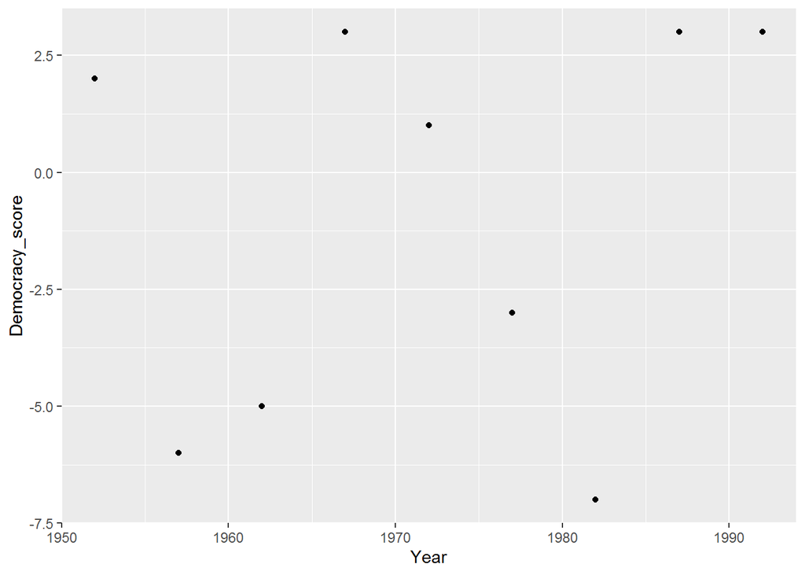

```r
guat_dem_tidy%>%ggplot(aes(Year,Democracy_score))+geom_point()
```